# Practical Machine Learning

Deepak Kalaikadal

2022-10-20

# Overview

This is the final project for *Practical Machine Learning* course on Coursera. This project will use data collected from fitness devices attached to waist, arm, dumb-bells of 6 participants in order to predict their exercise pattern, defined by the ‘classe’ variable in the available data. I have decided to use 3 models for training - **Decision Trees, Random Forest, and Gradient Boosted Tree** on the training set. The best model is used to predict a validation set partitioned from the training-data using its accuracy and out-of-sample error rate. The best model is then used to predict 20 cases defined in the Testing set.

## Importing Requisite Libraries

```r
knitr::opts_chunk$set()
#Importing requisite libraries

library(lattice)
library(ggplot2)
library(caret)
library(kernlab)
library(rattle)
library(corrplot)
set.seed(1358)
```

## Reading, Cleaning, and Partitioning the Training Dataset

We will remove variables with little relevance to the predictions, variables with near-zero variance, and columsn with largely N/A entries. We will then partition the training set to give a validation set and a training set.

```r
pml_training <- read.csv("C:/Users/deepa/Downloads/pml-training.csv")
pml_testing <- read.csv("C:/Users/deepa/Downloads/pml-testing.csv")
train.raw <- pml_training
test.raw <- pml_testing

#removing columns with NA > 80%
train.clean01 <- train.raw[,colMeans(is.na(train.raw)) < .8]
#removing variables which are time-based, which are irrelevant
train.clean02 <- train.clean01[,-c(1, grep("timestamp", names(train.clean01)) )]
#removing near-zero variance variables
train.clean03 <- train.clean02[,-nearZeroVar(train.clean02)]
train.clean04 <- train.clean03[,-1]
#Partitioning the Training-Set to give a Validation-Set
partition <- createDataPartition(y=train.clean03$classe, p=0.7, list=F)
train <- train.clean04[partition,]
valid <- train.clean04[-partition,]
```

## Correlation Analysis

Before we go onto training the models, a simple correlation analysis will help visualize the correlation among the variables

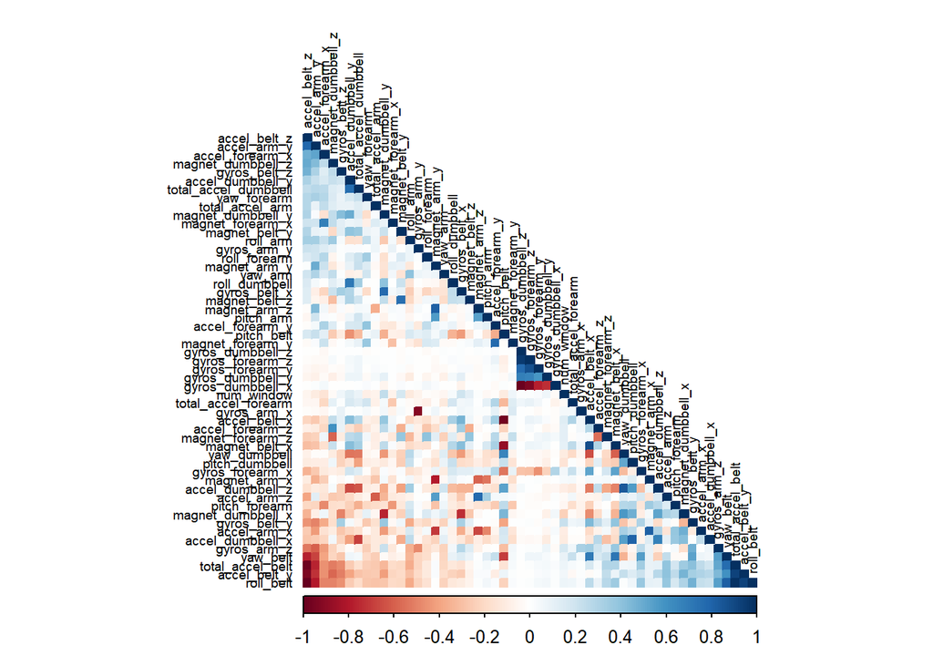

```r
corMatrix <- cor(train[, -54])
corrplot(corMatrix, order = "FPC", method = "color", type = "lower", tl.cex = 0.6, tl.col = rgb(0, 0, 0))
```

```r
control <- trainControl(method="cv", number=3, verboseIter=F)
```

In the correlation graph above, the highly correlated variables are shown as dark pixels (both red and blue).

## Training and Testing the Models

Like mentioned in the overview, we will be using three methods to model the regressions in the training set, and use the best amongst them for the testing-set. A confusion matrix is an excellent wa to visualize the accuracy of each model and is provided at the end of each analysis.

## Model 1 : Decision Tree

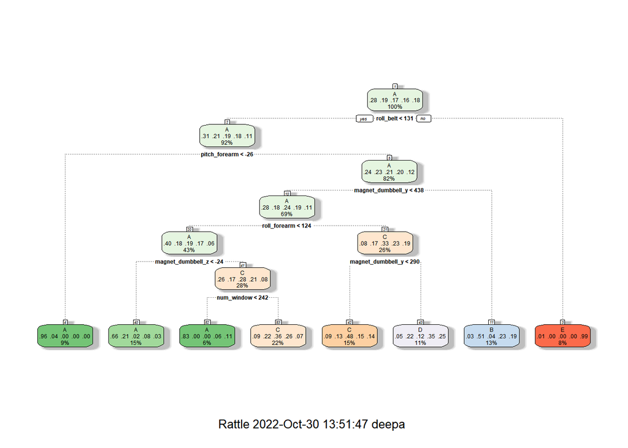

```r
#training model fit using the training-set
mod_trees <- train(classe~., data=train, method="rpart", trControl = control, tuneLength = 5)
fancyRpartPlot(mod_trees$finalModel)
```

```r
#prediction using the validation-set
pred_trees <- predict(mod_trees, valid)
cmtrees <- confusionMatrix(pred_trees, factor(valid$classe))
cmtrees
```

```
## Confusion Matrix and Statistics
##
##           Reference
## Prediction    A    B    C    D    E
##          A 1399  227   19   95   61
##          B   29  370   38  165  153
##          C  207  396  893  483  215
##          D   36  146   76  221  158
##          E    3    0    0    0  495
##
## Overall Statistics
##
##                Accuracy : 0.574
##                  95% CI : (0.5612, 0.5867)
##     No Information Rate : 0.2845
##     P-Value [Acc > NIR] : < 2.2e-16
##
##                   Kappa : 0.4606
##
##  Mcnemar's Test P-Value : < 2.2e-16
##
## Statistics by Class:
##
##                      Class: A Class: B Class: C Class: D Class: E
## Sensitivity            0.8357  0.32485   0.8704  0.22925  0.45749
## Specificity            0.9045  0.91888   0.7322  0.91546  0.99938
## Pos Pred Value         0.7768  0.49007   0.4070  0.34694  0.99398
## Neg Pred Value         0.9327  0.85010   0.9640  0.85842  0.89103
## Prevalence             0.2845  0.19354   0.1743  0.16381  0.18386
## Detection Rate         0.2377  0.06287   0.1517  0.03755  0.08411
## Detection Prevalence   0.3060  0.12829   0.3728  0.10824  0.08462
## Balanced Accuracy      0.8701  0.62186   0.8013  0.57236  0.72843
```

The **Decision Tree Model** only provides an **accuracy of 57.4%** when implemented on the validation test, with 2,507 out of sample errors out of 5885 observations. This is a little on the lower end of expectations. Let us see if another model is able to perform better. The Accuracy of the Decision Tree Model can be visualized below.

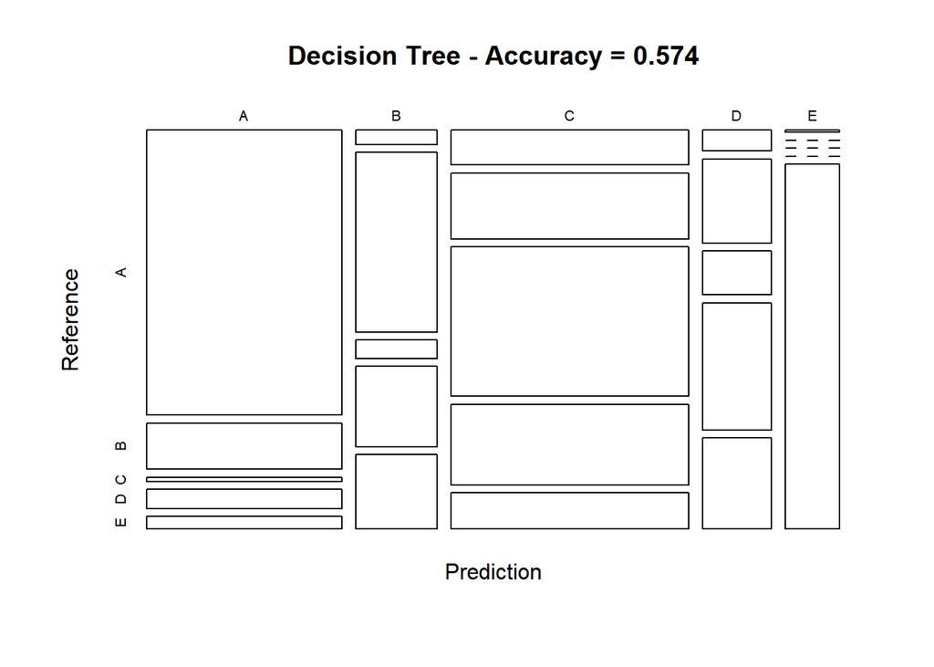

```r
plot(cmtrees$table, col = cmtrees$byClass,
     main = paste("Decision Tree - Accuracy =",
                  round(cmtrees$overall['Accuracy'], 4)))
```

## Model 2 : Random Forest

```r
#training model fit using the training-set
mod_rf <- train(classe~., data=train, method="rf", trControl = control, tuneLength = 5)
mod_rf <- train(classe~., data=train, method="rf", trControl = control)

#prediction using the validation-set
pred_rf <- predict(mod_rf, valid)
cmrf <- confusionMatrix(pred_rf, factor(valid$classe))
cmrf
```

```
## Confusion Matrix and Statistics
##
##           Reference
## Prediction    A    B    C    D    E
##          A 1674    1    0    0    0
##          B    0 1136    3    0    0
##          C    0    2 1023    4    0
##          D    0    0    0  959    0
##          E    0    0    0    1 1082
##
## Overall Statistics
##
##                Accuracy : 0.9981
##                  95% CI : (0.9967, 0.9991)
##     No Information Rate : 0.2845
##     P-Value [Acc > NIR] : < 2.2e-16
##
##                   Kappa : 0.9976
##
##  Mcnemar's Test P-Value : NA
##
## Statistics by Class:
##
##                      Class: A Class: B Class: C Class: D Class: E
## Sensitivity            1.0000   0.9974   0.9971   0.9948   1.0000
## Specificity            0.9998   0.9994   0.9988   1.0000   0.9998
## Pos Pred Value         0.9994   0.9974   0.9942   1.0000   0.9991
## Neg Pred Value         1.0000   0.9994   0.9994   0.9990   1.0000
## Prevalence             0.2845   0.1935   0.1743   0.1638   0.1839
## Detection Rate         0.2845   0.1930   0.1738   0.1630   0.1839
## Detection Prevalence   0.2846   0.1935   0.1749   0.1630   0.1840
## Balanced Accuracy      0.9999   0.9984   0.9979   0.9974   0.9999
```

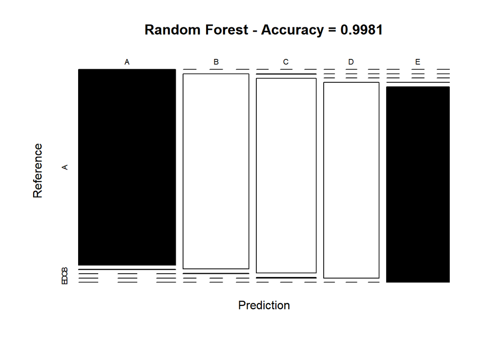

```r
plot(cmrf$table, col = cmrf$byClass,
     main = paste("Random Forest - Accuracy =",
                  round(cmrf$overall['Accuracy'], 4)))
```

## Model 3 : Gradient Boosted Tree

```r
#training model fit using the training-set
mod_gbm <- train(classe~., data=train, method="gbm", trControl = control, verbose = F)
#prediction using the validation-set
pred_gbm <- predict(mod_gbm, valid)
cmgbm <- confusionMatrix(pred_gbm, factor(valid$classe))
cmgbm
```

```
## Confusion Matrix and Statistics
##
##           Reference
## Prediction    A    B    C    D    E
##          A 1672   11    0    0    0
##          B    2 1114    8    5    9
##          C    0   10 1014   11    1
##          D    0    4    4  945    7
##          E    0    0    0    3 1065
##
## Overall Statistics
##
##                Accuracy : 0.9873
##                  95% CI : (0.9841, 0.99)
##     No Information Rate : 0.2845
##     P-Value [Acc > NIR] : < 2.2e-16
##
##                   Kappa : 0.9839
##
##  Mcnemar's Test P-Value : NA
##
## Statistics by Class:
##
##                      Class: A Class: B Class: C Class: D Class: E
## Sensitivity            0.9988   0.9781   0.9883   0.9803   0.9843
## Specificity            0.9974   0.9949   0.9955   0.9970   0.9994
## Pos Pred Value         0.9935   0.9789   0.9788   0.9844   0.9972
## Neg Pred Value         0.9995   0.9947   0.9975   0.9961   0.9965
## Prevalence             0.2845   0.1935   0.1743   0.1638   0.1839
## Detection Rate         0.2841   0.1893   0.1723   0.1606   0.1810
## Detection Prevalence   0.2860   0.1934   0.1760   0.1631   0.1815
## Balanced Accuracy      0.9981   0.9865   0.9919   0.9886   0.9918
```

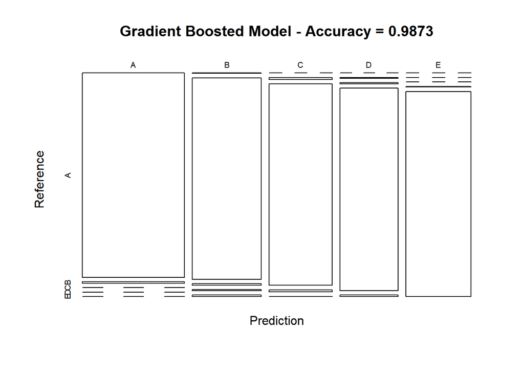

```r
plot(cmgbm$table, col = cmgbm$byClass,
     main = paste("Gradient Boosted Model - Accuracy =",
                  round(cmgbm$overall['Accuracy'], 4)))
```

## Applying Best Model to Test Data

From the above results based on the validation-set, it is very evident that the Random Forest Model has the highest accuracy and lowest out-of-sample errors. We will apply this model to the Testing Dataset.

```r
finalPredict <- predict(mod_rf, newdata=test.raw)
finalPredict
```

```
##  [1] B A B A A E D B A A B C B A E E A B B B
## Levels: A B C D E
```